# Report for merinov_gosl

## 1. The Data

Here is your dataset as we reprocessed it. Please take a look.

**Click to see the clean data**

```r
#|label: show_study_data
study_data
```

```
# A tibble: 0 × 18
# ℹ 18 variables: Entry <dbl>, Study <chr>, Region <chr>, Site <chr>,
#   Depth.m <dbl>, Sample.ID <chr>, Sample.Year <dbl>, Sample.Month <dbl>,
#   Sample.Day <dbl>, Latitude <dbl>, Longitude <dbl>, Taxon <chr>,
#   Fixed.or.Random <chr>, Sample.Unit.Size.sq.m <lgl>, Percent.Cover <dbl>,
#   Stipe.Density.num.per.sq.m <dbl>, Individual.Density.num.per.sq.m <dbl>,
#   Biomass.kg.wet.per.sq.m <dbl>
```

Here is your dataset as where we have now summed across all kelp species and put into the KelpTime main database format.

**Click to see the data in kelptime format**

```r
#|label: show_study_data
kelptime_study
```

```
# A tibble: 104 × 138
   study        site  period latitude longitude sample_unit_size_sq_m sasdate
   <chr>        <chr>  <dbl>    <dbl>     <dbl>                 <dbl> <date>
 1 merinov_gosl MSM        1     48.7     -68.0                  9999 2009-07-25
 2 merinov_gosl MSM        2     48.7     -68.0                  9999 2009-07-26
 3 merinov_gosl MSM        3     48.7     -68.0                  9999 2009-07-27
 4 merinov_gosl MSM        4     48.7     -68.0                  9999 2009-07-28
 5 merinov_gosl MSM        5     48.7     -68.0                  9999 2010-05-15
 6 merinov_gosl MSM        6     48.7     -68.0                  9999 2010-05-16
 7 merinov_gosl MSM        7     48.7     -68.0                  9999 2010-07-15
 8 merinov_gosl MSM        8     48.7     -68.0                  9999 2010-07-16
 9 merinov_gosl MSM        9     48.7     -68.0                  9999 2010-09-10
10 merinov_gosl MSM       10     48.7     -68.0                  9999 2010-09-11
# ℹ 94 more rows
# ℹ 131 more variables: max_depth <dbl>, mean_depth <dbl>, min_depth <dbl>,
#   biomass_kg_wet_per_sq_m <dbl>, stipe_density_num_per_sq_m <dbl>,
#   individual_density_num_per_sq_m <dbl>, percent_cover <dbl>, has_bm <dbl>,
#   has_sd <dbl>, has_id <dbl>, has_pc <dbl>, use_which <dbl>, focalKelp <dbl>,
#   focalUnit <chr>, geometry <chr>, ecoregion <fct>, province <chr>,
#   realm <chr>, focal_std_by_ecoregion <dbl>, focal_std_by_province <dbl>, …
```

## 2. Plots of raw data

### 2.1 By metric

Here is what your data looks like with all sites plotted together looking at each sampling metric.

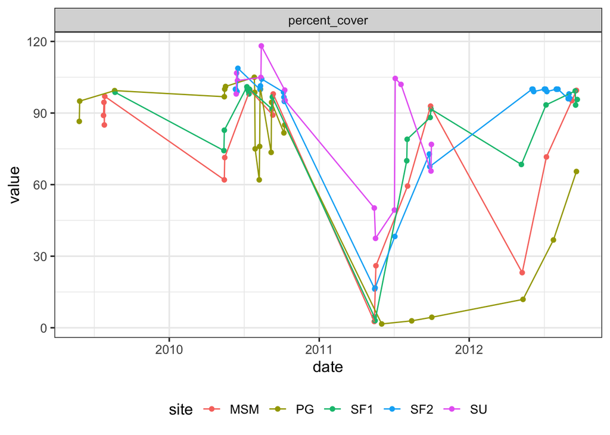

```r
kelptime_study_measurement_long <-
  kelptime_study |>
  tidyr::pivot_longer(cols =biomass_kg_wet_per_sq_m:percent_cover) |>
  filter(!is.na(value))

ggplot(kelptime_study_measurement_long,
       aes(x = date, y = value,
           color = site)) +
  geom_point() +
  geom_line() +
  facet_wrap(vars(name), scale = "free_y")
```

### 2.2 Standardized data

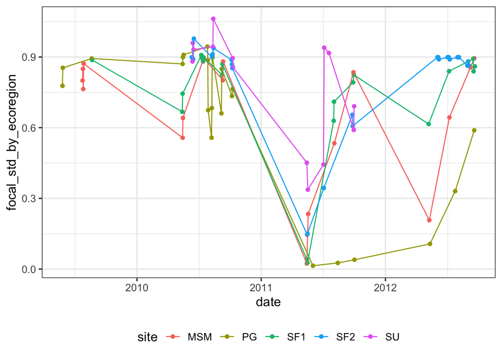

```r
ggplot(kelptime_study,
       aes(x = date, y = focal_std_by_ecoregion,
           color = site)) +
  geom_point() +
  geom_line()
```

### 2.3 Standardized data by site

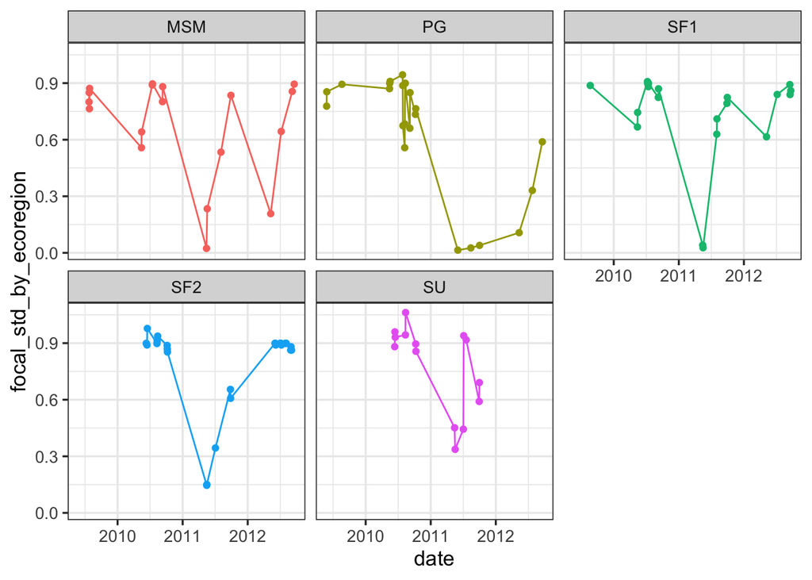

```r
ggplot(kelptime_study,
       aes(x = date, y = focal_std_by_ecoregion,
           color = site)) +
  geom_point() +
  geom_line() +
  facet_wrap(vars(site)) +
  guides(color = "none")
```

## 3. Modeled timeseries resuls

We fit two models. One where the slope varies by ecoregion (note: the GOSL and Newfoundland are collapsed) and one where the slope does not vary by ecoregion. Based on the modeled results, here is the smoothed fits to your data. Note - thus far, the model with a common slope appears to be the correct is the one with a common slope (best fit in terms of prediction and p-value for slope*ecoregion is not distinguishable from 0).

**Note** - the study (black) line might not line up in the middle or on trajectories, as it is shrunken in towards the grand mean for the ecoregion.

### 3.1 Slope Varying by Ecoregion Model

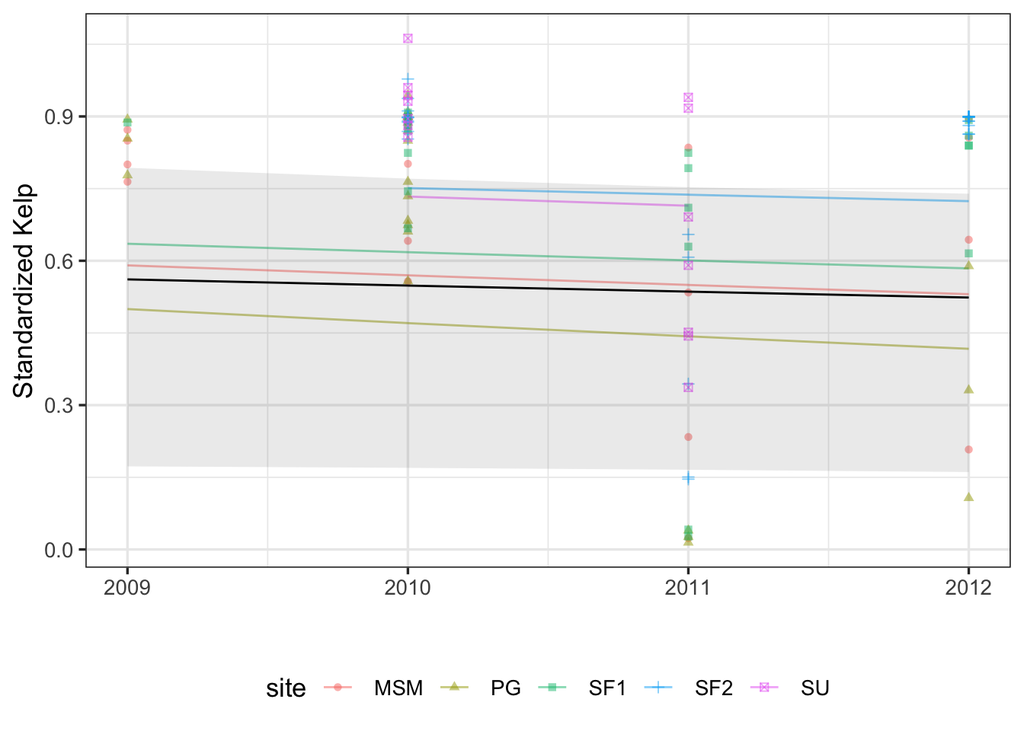

```r
mod_ecoregion <- readRDS("models/mod_ecoregion.rds")


# for plotting to do the back transform
exp_trans <- function(dat){

  dat |>
    mutate(
      Predicted = exp(Predicted)-0.01,
           CI_low = exp(CI_low)-0.01,
           CI_high = exp(CI_high)-0.01,
           CI_high = ifelse(CI_high>1.1, 1.1, CI_high)
    )|>
               mutate(trajectory =
                        gsub(study[1], "", trajectory))

}


re_ecoregion <- ranef(mod_ecoregion)$cond$study |>
  as_tibble(rownames = "study")  |>
  filter(study == params$study) |>
  pull(`(Intercept)`)


dat_fixed_ecoregion <- estimate_relation(mod_ecoregion,
                               include_random = FALSE,
                  length = 200,
                  data = kelptime_study) |>
  mutate(Predicted = Predicted + re_ecoregion) |>
  exp_trans()

dat_traj_ecoregion <- estimate_relation(mod_ecoregion,
                              include_random = TRUE,
                  length = 200,
                  data = kelptime_study) |>
    exp_trans()


ggplot(dat_traj_ecoregion, aes(x = year)) +
  geom_line(aes(y = Predicted,
                color = trajectory), alpha = 0.5) +
  geom_point(aes(y = focal_std_by_ecoregion,
                 group = trajectory,
                 shape = trajectory,
                 color = trajectory), alpha = 0.5,
             data = kelptime_study |>
               mutate(trajectory =
                        gsub(study[1], "", trajectory))) +
  geom_line(data = dat_fixed_ecoregion,
            aes(y = Predicted), color = "black") +
  geom_ribbon(data = dat_fixed_ecoregion,
            aes(y = Predicted,
                ymin = CI_low,
                ymax = CI_high), color = NA,
            alpha = 0.1) +
  labs(x = "", y = "Standardized Kelp",
      color = "site", shape = "site")
```

### 3.2 Common Slope Model

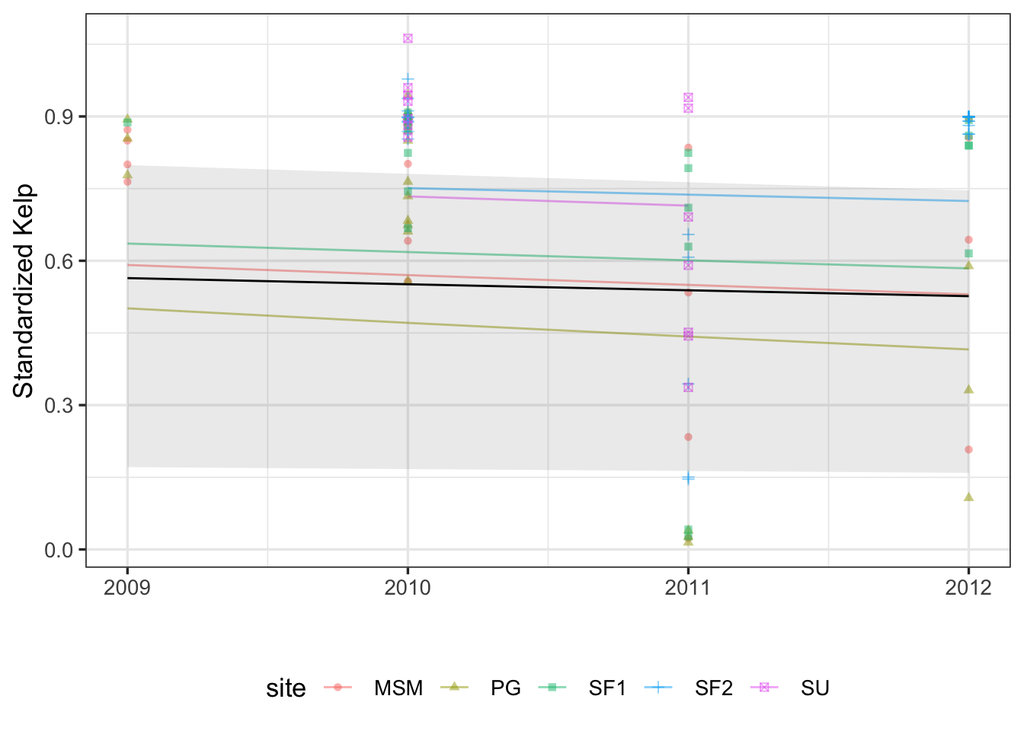

```r
mod_common_slope <- readRDS("models/mod_common_slope.rds")

re <- ranef(mod_common_slope)$cond$study |>
  as_tibble(rownames = "study")  |>
  filter(study == params$study) |>
  pull(`(Intercept)`)


dat_fixed <- estimate_relation(mod_common_slope,
                               include_random = FALSE,
                  length = 200,
                  data = kelptime_study) |>
  mutate(Predicted = Predicted + re) |>
  exp_trans()

dat_traj <- estimate_relation(mod_common_slope,
                              include_random = TRUE,
                  length = 200,
                  data = kelptime_study) |>
    exp_trans()

ggplot(dat_traj, aes(x = year)) +
  geom_line(aes(y = Predicted,
                color = trajectory), alpha = 0.5) +
  geom_point(aes(y = focal_std_by_ecoregion,
                 group = trajectory,
                 shape = trajectory,
                 color = trajectory), alpha = 0.5,
             data = kelptime_study |>
               mutate(trajectory =
                        gsub(study[1], "", trajectory))) +
  geom_line(data = dat_fixed,
            aes(y = Predicted), color = "black") +
  geom_ribbon(data = dat_fixed,
            aes(y = Predicted,
                ymin = CI_low,
                ymax = CI_high), color = NA,
            alpha = 0.1) +
  labs(x = "", y = "Standardized Kelp",
      color = "site", shape = "site")
```